# Lab2

Joshua Wiseman

2023-01-27

# Tasks

## Task 1

Working directory:

```r
getwd()
```

```
## [1] "/home/joshua/Desktop/MainFolder/OuClasses/Spring 2023/Applied Statistical Methods/FALL224753wise0046/LABS/LAB2"
```

## Task 2

```r
epagas <- read.csv("EPAGAS-1.csv")
head(epagas)
```

```
##    MPG
## 1 36.3
## 2 41.0
## 3 36.9
## 4 37.1
## 5 44.9
## 6 36.8
```

## Task 3

1. Make the object mpg, the number of miles per gallon vector.

```r
mpg = epagas$MPG
head(mpg)
```

```
## [1] 36.3 41.0 36.9 37.1 44.9 36.8
```

2. If $z_i=\frac{x_i-\bar{x}}{s_x}$, then $\bar{z}=0$ and $s^2_z=1$. Transform the mpg variable to z and verify these results.

```r
z = (mpg - mean(mpg)) / sd(mpg)
head(z)
```

```
## [1] -0.28702628  1.65681163 -0.03887676  0.04383975  3.26978352 -0.08023501
```

```r
print(paste0("mean = ", round(mean(z), digits = 4)), quote = FALSE)
```

```
## [1] mean = 0
```

```r
print(paste0("variance = ", var(z)), quote = FALSE)
```

```
## [1] variance = 1
```

```r
print(paste0("standard deviation = ", sd(z)), quote = FALSE)
```

```
## [1] standard deviation = 1
```

3. Using z, find the values of mpg that are possible outliers.

```r
mpg[abs(z) >= 2 & abs(z) <= 3]
```

```
## [1] 30.0 42.1 31.8
```

4. Using z, find the values of mpg that defined as outliers.

```r
mpg[abs(z) > 3]
```

```
## [1] 44.9
```

5. Using the lattice package construct a dotplot with colors, Red=outlier, Blue=possible outlier. (NB – read the instructions in the lab2.r file for installing the package)

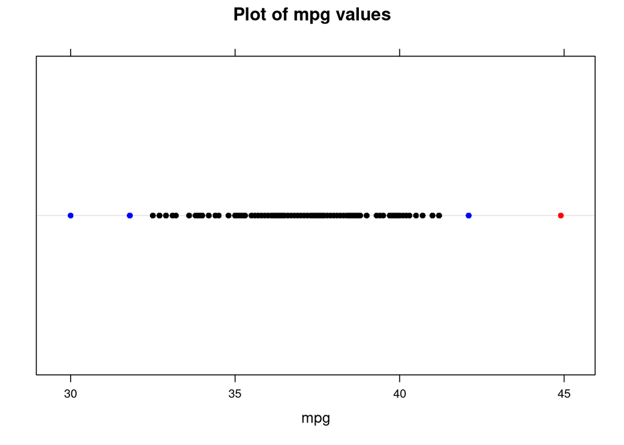

```r
mycol = ifelse(abs(z) > 3, "red",
        ifelse(abs(z) >= 2 & abs(z) <= 3,"blue", "black"))
library(lattice)
dotplot(mpg, col = mycol, main = "Plot of mpg values")
```

## Task 4

1. Make a boxplot of the mpg variable. Make the box black. Put a notch where the median goes. Put a title on the graph. Make the plot horizontal.

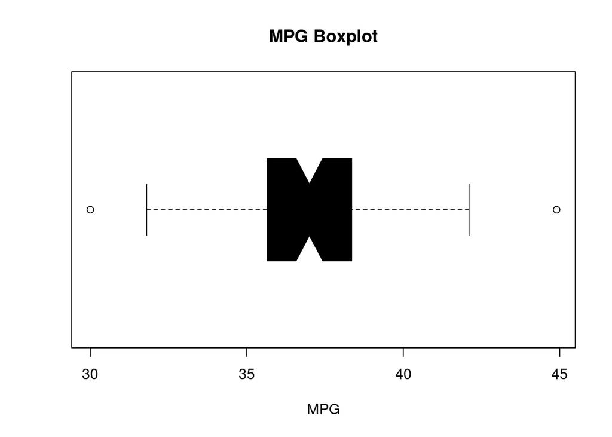

```r
boxplot(mpg, main = "MPG Boxplot", xlab = "MPG", col = "black", horizontal = TRUE, notch = TRUE)
```

2. Using Chebyshev’s theorem, $1 - \frac{1}{k^2}$, predict the proportion of data within 2 standard deviations of the mean of the mpg data.

```r
k = 2
cheb = 1 - 1 / (k ^ 2)
cheb
```

```
## [1] 0.75
```

3. Use R to calculate the exact proportion within 2 standard deviation of the mean.

```r
exacttwo = length(mpg[abs(z) < 2]) / length(mpg)
exacttwo
```

```
## [1] 0.96
```

4. Does Chebyshev agree with the data? `Yes`
5. Now use the empirical rule, what proportion (according to the rule) of the data should be within 2 standard deviations of the mean? `95%`
6. How well does it correspond? `Pretty well! 96% is very close to 95%.`
7. Is the Empirical rule valid in this case? Why? `Yes. As shown by the histogram, it has the mound-shaped & symmetric distribution.`

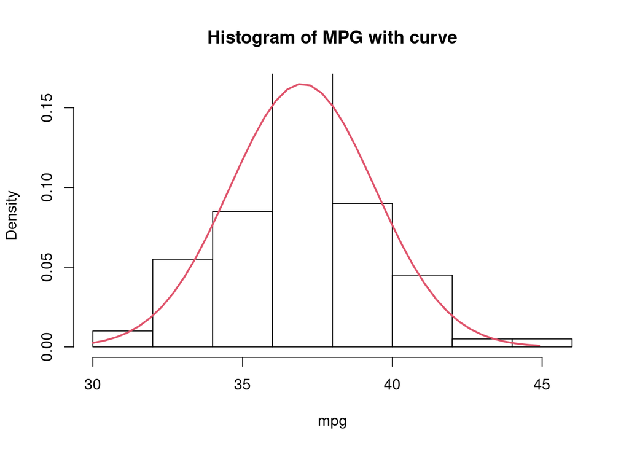

```r
# X-axis grid
mpg2 <- seq(min(mpg), max(mpg), length = 40)
# Normal curve
curve <- dnorm(mpg2, mean = mean(mpg), sd = sd(mpg))
# Histogram
hist(mpg, prob = TRUE, col = "white",
   ylim = c(0, max(curve)),
   main = "Histogram of MPG with curve")
lines(mpg2, curve, col = 2, lwd = 2)
```

```r
# Credit: https://r-charts.com/distribution/histogram-curves/
```